# A Previdência no Twitter

# O twiiter na previdência

Desde o começo do atual governo brasileiro muito se fala sobre a proposta de uma reforma da previdência. Desde então toda a comunidade política vem se manifestando acerca do tema, sejam elas declarações de apoio, propondo algum tipo de alteração no sistema previdenciário brasileiro ou contrapondo-se a qualquer mudança no atual sistema. Muito se falou (e ainda se fala) sobre o assunto, principalmente após o poder executivo ter encaminhado à câmara um texto base para reforma o sistema previdenciário nacional atual. Alguns atores políticos criticaram por acreditar que o atual sistema é viável, outros criticaram e fazem propostas de outras possíveis alternativas de previdência que não são a atual nem a encaminhada pelo governo, além dos que defenderam o a aprovação na íntegra do texto proposto pela equipe do presidente.

As redes sociais se tornaram uma espécie de assembleia popular permanente, na qual todos os atores políticos (sejam pessoas exercendo mandato político, ou mesmo um cidadão comum da sociedade civil) declaram suas opiniões e de forma muita fácil e ágil e obtêm retorno dos usuários que com eles interagem. Uma das principais plataformas utilizadas para estes debates é o Twitter, e é nele que muitos - deputados, senadores, presidente, ministros, dentre outros - se manifestam. Durante o debate da reforma da previdência não foi diferente, muito foi dito sobre o tema tentando convencer a opinião pública de que lhes pareciam ser a melhor decisão a ser tomada.

Mas será que houve alguma diferença nos discursos dos políticos? Eles foram ácidos ou brandos em suas declarações? Quem teve mais repercussão nas suas declarações?

Para tentar responder algumas destas perguntas utilizamos algumas abordagens estatísticas para sumarizar algumas informações nas declarações no twitter desde o dia 01/01/2019 até o dia da aprovação da reforma em primeiro turno na câmara dos deputadas, dia 10/07/2019. Consideramos alguns atores que consideramos mais relevantes para o processo, foram eles:

- Jair Bolsonaro (@jairbolsonaro) - Presidente da Republica (PSL)
- Joice Hasselman (@joicehasselmann) - Deputada Federal (PSL)
- Kim Kataguiri (@kimpkat) - Deputado Federal (DEM)
- Arthur do Val (@mamaefalei) - Deputado Estadual - SP (DEM)
- Tábata Amaral (@tabataamaralsp) - Deputada Federal (PDT)
- Gleisi Hoffmann (@gleisi) - Deputada Federal (PT)
- Guilherme Boulos (@GuilhermeBoulos) - Ex-candidato a presidência (PSOL)
- Marcelo Freixo (@MarceloFreixo) - Deputado Federal (PSOL)

# O quanto publicam os políticos

Nós coletamos todas publicações realizadas pelos políticos através dos dados que a API do Twitter nos fornece, que são cerca de 3.200 publicações de cada candidato. Então filtramos apenas publicações no período de interesse e que continham a palavra “previdência” inclusa no texto da publicação. Então abaixo estão a quantidade de publicações realizadas por eles que atendiam a nossa filtragem.

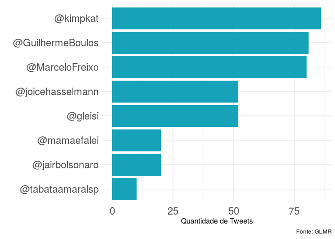

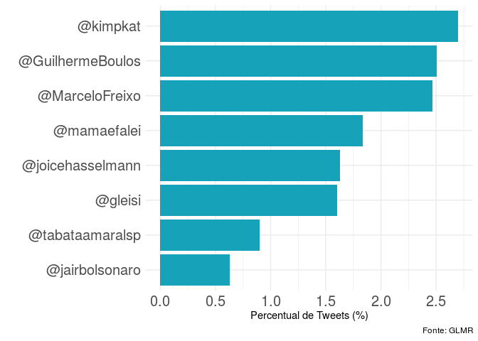

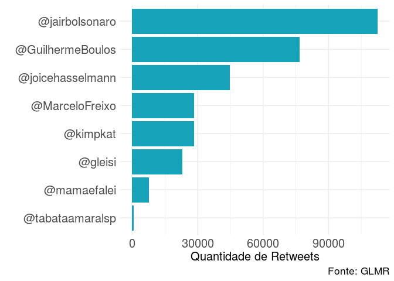

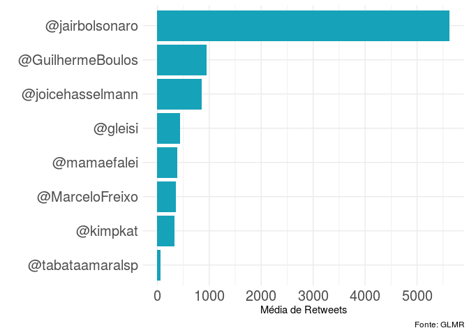

# Analisando os sentimentos

Para a análise de sentimento foram excluídas as palavras conectivas, foram utilizadas palavras disponíveis [**aqui**](https://github.com/stopwords-iso/stopwords-pt/blob/master/stopwords-pt.txt).

Primeiramente foi observado as cinco palavras mais utilizadas pelos políticos nas suas publicações. Todos eles tiveram como mais repetida a palavra “reforma”, o único a ser exceção é o presidente. Ele mais utilizou, de forma balanceada, as palavras: militares, brasil, aprovação, reforma e emprego. A deputada Joice, o deputado Freixo, a deputada Gleise e o ex-candidato Boulos, tinham como uma das palavras mais citada o nome do próprio presidente. Esta observação conduz a possibilidade de alem de tratar do tema da previdência nas publicações, eles falam conjuntamente do presidente, seja atacando ou concordando. Os outros políticos não tiveram a mesma característica. Bolsonaro, Joice, Gleise e Boulos também tiveram em comum menções ao país.

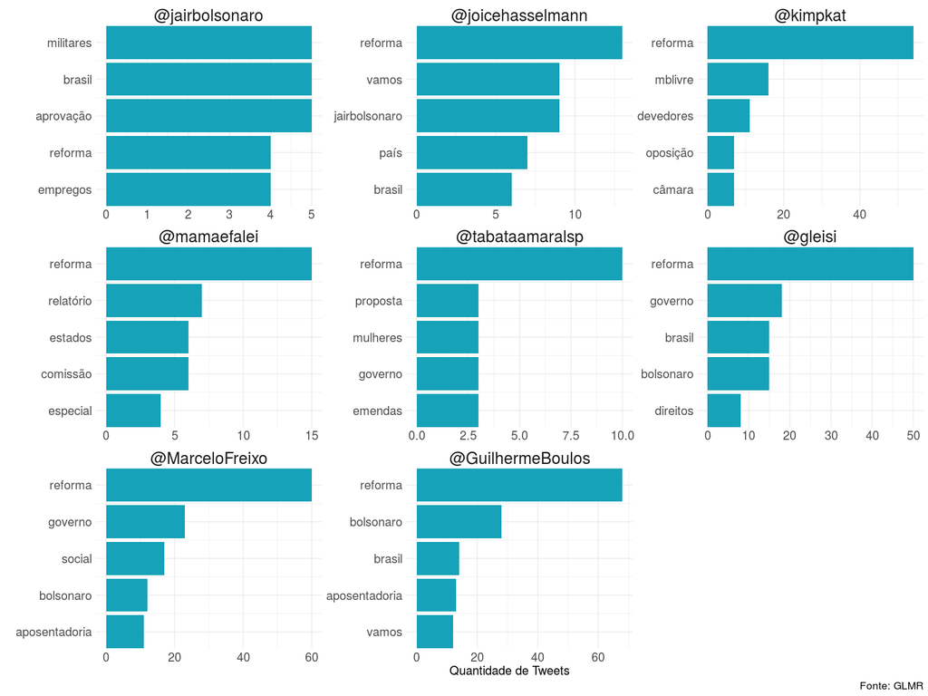

O método de análisar os sentimentos de um texto, da forma mais que existe básica (para saber mais acessar [**aqui**](https://saifmohammad.com/WebPages/NRC-Emotion-Lexicon.htm)), consite em avaliar a quantidade de palavras posítivas e negativas, fazer a diferênça destas quantidades e desta diferênça se obterm um indicador de sentimento do texto.

Como havia uma diferença nos tamanhos das publicações, foi resolvido que ao invés de utilizar a contagem de palavras positivas e negativas, utilizamos as proporções de palavras positivas e negativas, e em seguida padroniza-lo, assim obtivemos um indicador, que sintetiza esta diferença de humor.

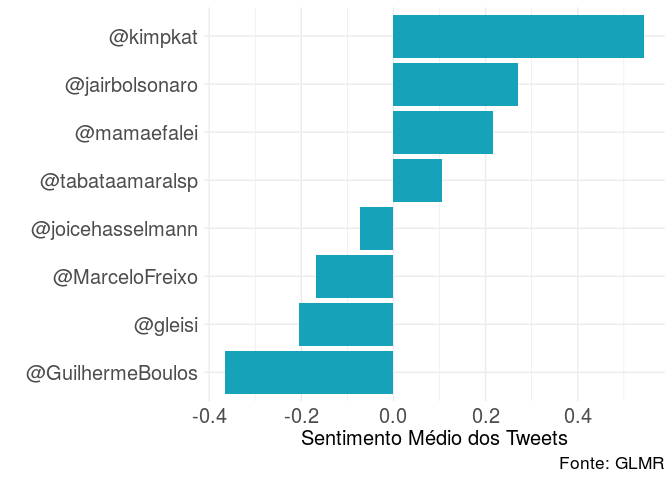

Escolhemos uma estratégias para avaliar a similaridade entre os sentimentos das postagens de todos eles que foi a análise de cluster, também conhecida como análise de agrupamento (saiba mais [**aqui**](https://www.inf.ufsc.br/~aldo.vw/patrec/agrupamentos.html)). Em linhas gerais, trata-se de uma técnica multivariada, no qual os indivíduos são agrupados de acordo com suas semelhanças, observando várias variáveis ao mesmo tempo. Neste caso, utilizaremos a proporção média (padronizada) de palavras de cada sentimento contidas nas publicações dos políticos. Isto nos gerou um indicador que assume valores, aproximadamente entre -4 e 4, no qual quanto mais próximo de -4 denota pouco uso de uma dada emoção e mais próximo de 4 muito uso.

Ao ser avaliado o dendograma chegamos ao número hipotético de que os políticos formavam 4 grupos. Utilizando o método K-menas, eles foram agrupados seguiram a seguinte composição:

- Grupo 1: Jair Bolsonaro (@jairbolsonaro);
- Grupo 2: Gleisi Hoffmann (@gleisi); Guilherme Boulos (@GuilhermeBoulos) e Marcelo Freixo (@MarceloFreixo);
- Grupo 3: Joice Hasselman (@joicehasselmann) e Tábata Amaral (@tabataamaralsp);
- Grupo 4: Kim Kataguiri (@kimpkat) e Arthur do Val (@mamaefalei)

### Sentimentos dos políticos

| Grupo | Politicos | Positivo | Negativo | Raiva | Antecipação | Nojo | Medo | Alegria | Tristeza | Surpresa | Confiante |
| --- | --- | --- | --- | --- | --- | --- | --- | --- | --- | --- | --- |
| 1 | @jairbolsonaro | 0.074 | -0.195 | -0.377 | -0.165 | -0.342 | -0.261 | 0.166 | -0.225 | 0.204 | 0.299 |
| 2 | @gleisi | 0.096 | 0.301 | 0.111 | -0.300 | 0.257 | 0.315 | 0.025 | 0.371 | 0.051 | 0.042 |
| 2 | @GuilhermeBoulos | -0.283 | 0.082 | 0.211 | -0.086 | -0.007 | 0.128 | -0.068 | 0.054 | -0.061 | -0.440 |
| 2 | @MarceloFreixo | 0.000 | 0.168 | 0.207 | 0.190 | -0.057 | 0.273 | 0.183 | 0.108 | 0.062 | -0.016 |
| 3 | @joicehasselmann | -0.382 | -0.309 | -0.336 | -0.388 | -0.071 | -0.407 | -0.076 | -0.381 | -0.077 | -0.093 |
| 3 | @tabataamaralsp | -0.146 | -0.252 | -0.219 | -0.508 | -0.421 | -0.277 | -0.160 | -0.298 | -0.178 | -0.112 |
| 4 | @kimpkat | 0.367 | -0.176 | -0.115 | 0.415 | 0.013 | -0.262 | -0.087 | -0.117 | 0.037 | 0.339 |
| 4 | @mamaefalei | 0.311 | 0.094 | -0.114 | 0.012 | 0.270 | 0.160 | -0.037 | 0.251 | -0.209 | 0.273 |

### Sentimento Médio por Gurpo de Políticos

| Grupos | Positivo | Negativo | Raiva | Antecipação | Nojo | Medo | Alegria | Tristeza | Surpresa | Confiante |
| --- | --- | --- | --- | --- | --- | --- | --- | --- | --- | --- |
| 1 | 0.074 | -0.195 | -0.377 | -0.165 | -0.342 | -0.261 | 0.166 | -0.225 | 0.204 | 0.299 |
| 2 | -0.062 | 0.184 | 0.176 | -0.065 | 0.064 | 0.238 | 0.047 | 0.178 | 0.017 | -0.138 |
| 3 | -0.264 | -0.280 | -0.278 | -0.448 | -0.246 | -0.342 | -0.118 | -0.340 | -0.127 | -0.102 |
| 4 | 0.339 | -0.041 | -0.115 | 0.213 | 0.142 | -0.051 | -0.062 | 0.067 | -0.086 | 0.306 |

Os resultados aparentam descrever bem as figuras políticas quem realizaram as publicações na maior parte dos sentimentos destacados.

Para reproduzir todos os resultados, entre em contato que forneceremos os dados.